# PSY 8960 Week 8 Project

Saron Demeke

2023-03-20

**Reproducible Image and Online Resources**

An image of this project as of *2023-03-20* can be accessed by [clicking this link](https://mybinder.org/v2/gh/sdemeke/psy8960-week8.git/HEAD?urlpath=rstudio).

An interactive web app is available by [clicking this link](https://sdemeke.shinyapps.io/shiny_week8/) instead.

**Script Settings and Resources**

```r
#excluding the setwd() because knitting returns an error with it. everything is working without explicit setting of wd.
library(tidyverse)
```

**Data Import and Cleaning**

The following code chunk imports `week3.csv`, suppresses the column specification message, and executes a series of data cleaning steps, including reverse coding of Q5 and computing row-wise mean scores across specified subsets of questions using the complementary `rowwise()` and `c_across()` functions in `dplyr` package.

```r
week8_tbl <- read_csv("../data/week3.csv",show_col_types = FALSE) %>%
  mutate(q5 = abs(q5-6)) %>%
  rowwise() %>%
  mutate(mn_q1q6 = mean(c_across(q1:q6)),
         mn_q8q10 = mean(c_across(q8:q10)))
```

**Visualization**

The following section displays the raw values for scores on selected columns Q1-Q6 (Q5 has been reverse coded) and a scatterplot of the mean scores on Q1-Q6 vs mean scores on Q8-Q10 with an overlayed regression line (purple) and standard error band.

| q1 | q2 | q3 | q4 | q5 | q6 |
| --- | --- | --- | --- | --- | --- |
| 5 | 4 | 4 | 1 | 2 | 1 |
| 2 | 4 | 3 | 1 | 3 | 1 |
| 5 | 5 | 2 | 1 | 5 | 1 |
| 4 | 3 | 4 | 2 | 4 | 1 |
| 3 | 1 | 3 | 5 | 2 | 1 |
| 4 | 3 | 2 | 3 | 3 | 1 |
| 2 | 4 | 1 | 3 | 1 | 1 |
| 4 | 2 | 5 | 1 | 1 | 1 |
| 2 | 5 | 3 | 4 | 2 | 1 |
| 3 | 4 | 2 | 4 | 5 | 1 |

[output cut: 39 more lines]

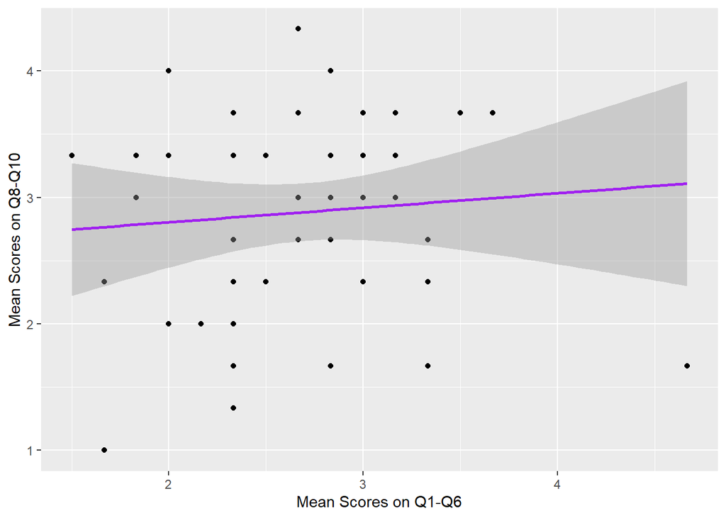

**Analysis**

The following section displays the results for a correlation test between mean scores on Q1-Q6 vs mean scores on Q8-10. The observed correlation is 0.08. The p-value of 0.56 suggests that the association between the mean scores on the two subsets of questions is not stastically significant and we would fail to reject the null hypothesis that the correlation is 0.

```r
cor.test(week8_tbl$mn_q1q6,week8_tbl$mn_q8q10)
```

```
##
##  Pearson's product-moment correlation
##
## data:  week8_tbl$mn_q1q6 and week8_tbl$mn_q8q10
## t = 0.58309, df = 47, p-value = 0.5626
## alternative hypothesis: true correlation is not equal to 0
## 95 percent confidence interval:
##  -0.2012466  0.3574248
## sample estimates:
##        cor
## 0.08474575
```

**Data Export**

The following code chunk excludes variables that are not necessary for the Shiny app to run and saves the data in format appropriate for shiny. Gender is recoded as a factor for easier filtering in shiny and the completed time variable is also recoded as POSIXct/POSIXt for easier selection and filtering.

```r
week8_tbl %>%
 select(c(gender,timeEnd,mn_q1q6,mn_q8q10)) %>%
 mutate(gender = factor(gender,levels=c("M","F"),labels=c("Male","Female"))) %>%
 mutate(timeEnd =  ymd_hms(timeEnd,truncated = 3)) %>%
 saveRDS(file = "../shiny_week8/week8_shinydata.rds")
```